# Final Assignment

Bakari Moitt

2023-02-06

Intro:  
Hi and welcome to my final project presentation. Below I will build graphs to replicate that of a scientific report published by Erica Crespi of Washington State University. The report is about the widespread issue of highly effective but detrimental pesticides among quails. They are looking at ways to protect the Galapagos finches from invasive parasites.

Initially, my plan was to make a personal website detailing the movies that I had watched during j-term and ranking them accordingly, but that proved to be quite difficult. Since I could only start on the final project post our class on Tuesday I was not able to get any troubleshooting help, so I decided making graphs was the next best thing. I will replicate Figure 4 of the data.

Step 2: Upload your data: 1.

```r
library(ggplot2)
library(ggthemes)
library(tidyr)

Quail1<- read.table(file="final project/Trans-ovo quail 15.csv", header = TRUE, sep = ",")
head(Quail1)
```

```
##          Nest Permethrin Number Heart.Mass..g. Heart.Length..mm.
## 1 .2 g cotton    Control      1         0.0334              5.29
## 2 .2 g cotton    Control      2         0.0355              6.23
## 3 .2 g cotton    Control      3         0.0206              4.83
## 4 .2 g cotton    Control      4         0.0337              6.53
## 5 .2 g cotton    Control      5         0.0251              5.29
## 6 .2 g cotton    Control      6         0.0312              5.66
##   Heart.Width..mm. Heart.Depth..mm. Mass..g. Right.Tarsus..mm. Beak..mm.
## 1             3.90             3.04   3.9571             12.54     5.137
## 2             3.90             3.63   4.3403             13.07     6.370
## 3             3.21             3.16   3.2672             10.78     5.344
## 4             4.58             3.32   4.8308             13.25     4.655
## 5             3.74             2.49   3.3593             11.59     4.938
## 6             3.69             3.08   4.5668             13.51     6.669
##    Toe..mm. Eye.Diameter..mm. Head.Diameter..mm. Heart.rates
## 1  8.556757             4.668             15.900         264
## 2  8.966975             4.587             15.771         338
## 3  8.401623             4.085             17.166          NA
## 4  9.539726             3.855             17.646         285
## 5  8.612118             4.122             15.075          NA
## 6 10.761066             4.267             15.776         209
```

```r
Quail2<- read.table(file="final project/Trans-ovo qual 5.csv", header = TRUE, sep = ",")
head(Quail2)
```

```
##   Embryo.Number Nest.Cotton.Weight Dose Treatment Mass Heart.Rate Stage
## 1             1                0.8    0   Control 0.38      132.6    33
## 2             2                0.8    0   Control 0.51       84.0    32
## 3             3                0.8    0   Control 0.48      105.0    31
## 4             4                0.8    0   Control 0.40      102.3    33
## 5             5                0.8    0   Control 0.48      110.0    31
## 6             6                0.8    0   Control 0.58      106.6    33
##   Head.Width..mm. Eye.Width..mm. Body.Length..mm. Hindbrain..Fluid.Solid
## 1           7.214          4.396           17.685                  Fluid
## 2           5.810          3.131           16.984                  Fluid
## 3           7.173          3.459           18.606                  Fluid
## 4           6.644          5.016           17.518                  Fluid
## 5           7.579          4.590           15.673                  Fluid
## 6          10.853          6.375           18.755                  Fluid
##   Forebrain..Fluid.Solid Forebrain.Width..mm. Forebrain.Height..mm.
```

[output cut: 27 more lines]

Step 3: Figure 4 Here is a picture of my intended replication:

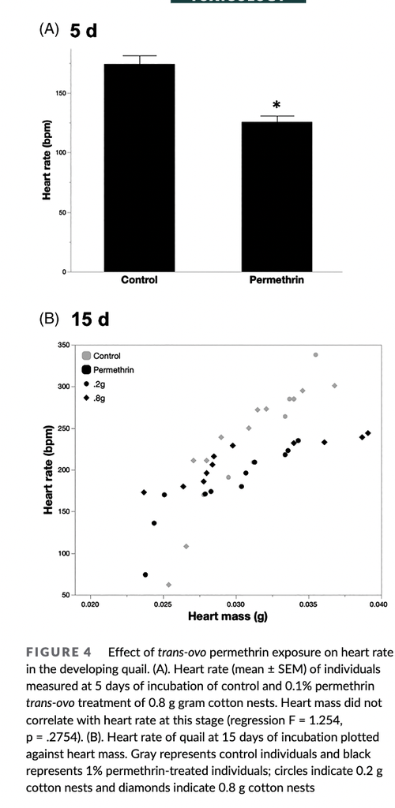

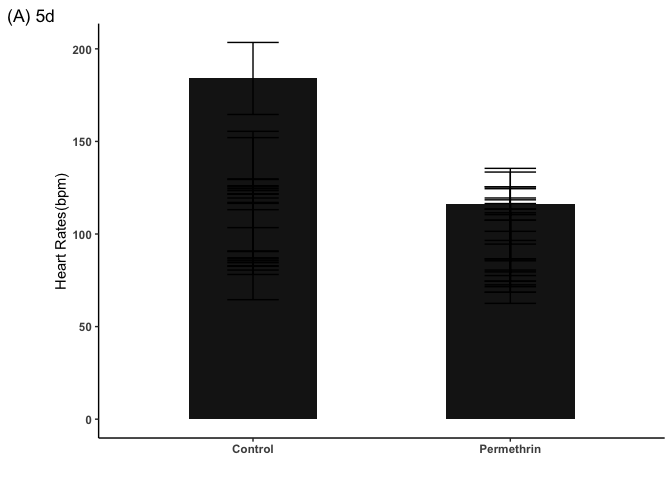

```r
### Making graph 1

#information for standard error bars
se<- sd(Quail2$Heart.Rate)/29
sed<- c(rep(se,29))
m<- mean(Quail2$Heart.Rate)
mean<- c(rep(m,29)
        )
se1 <- Quail2$Heart.Rate- sd(Quail2$Heart.Rate)
se2 <- Quail2$Heart.Rate + sd(Quail2$Heart.Rate)
G<- cbind(Quail2, se1, se2)

#graphing
G1<- ggplot(data=G,
              aes(x= Treatment, y=Heart.Rate, fill= Treatment)) + geom_bar(position="dodge", stat="identity", width=0.5, show.legend=FALSE) +
  ylab("Heart Rates(bpm)") +
  xlab("") +
  labs( tag="(A) 5d")
#establishing themes and presentation changes
G1F<- G1 +  theme_classic() + scale_fill_grey(start=.1, end=.1) + geom_errorbar(aes(ymin=se1, ymax=se2), width=0.2) + theme(axis.text.y = element_text(face="bold"), axis.text.x = element_text(face="bold"))
G1F
```

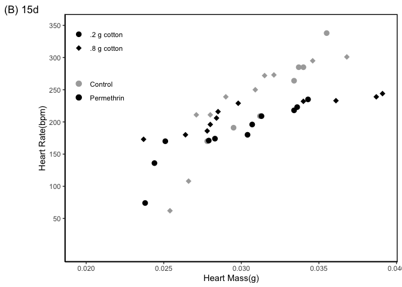

```r
### Making graph 2
 G2<- ggplot(data=Quail1,
              aes(x= Heart.Mass..g., y=Heart.rates, color=Permethrin, shape= Nest)) + geom_point(size=3.0)

G2F<- G2+ theme_classic() + theme(legend.position = c(0.1, 0.8), legend.title=element_blank()) + scale_shape_manual(values= c(16, 18)) + scale_y_continuous(name="Heart Rate(bpm)", limits=c(0, 350), breaks = c(50, 100, 150, 200, 250, 300, 350)) + xlab("Heart Mass(g)") + theme(panel.background=element_rect(colour="black", size=1)) + scale_color_manual(values=c(Control="darkgrey", Permethrin="black")) + labs( tag="(B) 15d")
G2F
```

Step 4: Panel

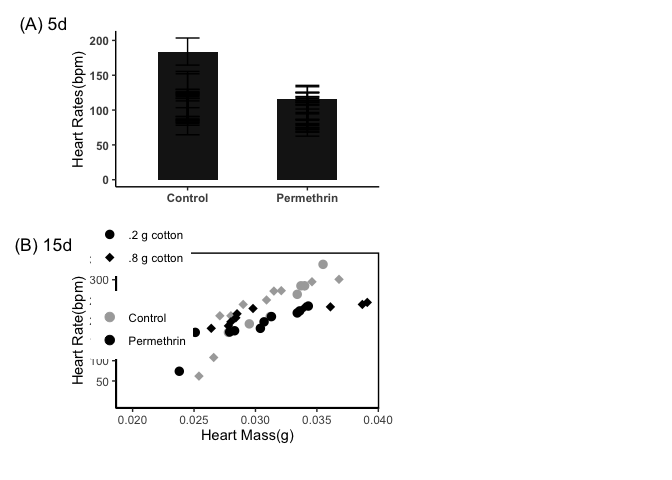

```r
library(patchwork)
( G1F + plot_spacer() ) /(G2F + plot_spacer()) + plot_spacer() +
plot_layout(heights = c(10,10,0.5))
```

Step 5: Plausible troubleshooting: 1. There were multiple issues that I came across while making the graphs, mainly, I could not properly get the error bars on the first graph.  
- I tried to make functions that created error bar data, but the error bars were the wrong size.  
- I tried to addi in new columns with data for error bars, but it did made the graph red.  
- eventually, I did each bit of data separately then made columns and that was the most accurate that I have been.

2. For graph 2, I could not get the colors of the dots to change.  
   - I tried scale_fill_grey, but the color would only be black.  
   I tried scale_color_grey, but the color would remain the same.  
   Finally, I tried scale_color_manual and wrote the exact colors for each sections and it worked.
3. For creating the panel, I had an issue with modifications not transferring over. - I fiddled with it for a while until I decided to make the modifications be considered a separate graph ( i.e G1F and G2F)
4. For creating the panel, the graph was being stretched. - I tried to adjust height and width using plot_layout ( heights, weights) but that did not work. - I ended up adding in plot spaces to squish the data’s width. The legend was still messing up, so i assume they stretched the panel in a different program
5. An issue with bolding. - I attempted to bold the words for each graph but they were not as bold as I needed it to be, so I assume they typed over the sides in a different program.